# Graded Project

### Graded Project

Machine Learning - Unsupervised Learning

### Domain:

### Business Context:

● Customer segmentation is one of the most important marketing tools at your disposal, because it can help a business to better understand its target audience. This is because it groups customers based on common characteristics.

● Segmentation can be based on the customer’s habits and lifestyle, in particular, their buying habits. Different age groups, for example, tend to spend their money in different ways, so brands need to be aware of who exactly is buying their product.

● Segmentation also focuses more on the personality of the consumer, including their opinions, interests, reviews, and rating. Breaking down a large customer base into more manageable clusters, making it easier to identify your target audience and launch campaigns and promote the business to the most relevant people

### Dataset Description:

The dataset contains measurements of clothing fit from RentTheRunway. RentTheRunWay is a unique platform that allows women to rent clothes for various occasions. The collected data is of several categories. This dataset contains self-reported fit feedback from customers as well as other side information like reviews, ratings, product categories, catalog sizes, customers’ measurements (etc.)

### Data Citation:

● Rishabh Misra, Mengting Wan, Julian McAuley "Decomposing Fit Semantics for Product Size Recommendation in Metric Spaces". RecSys, 2018.  
● Rishabh Misra, Jigyasa Grover "Sculpting Data for ML: The first act of Machine Learning". 2021.

### Project Objective:

Based on the given users and items data of an e-commerce company, segment the similar user and items into suitable clusters. Analyze the clusters and provide your insights to help the organization promote their business.

### ● Import the required libraries :

```python
import pandas as pd
import numpy as np
import matplotlib.pyplot as plt
import seaborn as sns
from sklearn.preprocessing import StandardScaler
from sklearn.decomposition import PCA
from sklearn.cluster import KMeans
from sklearn.metrics import silhouette_score
from sklearn.cluster import AgglomerativeClustering
from scipy.cluster.hierarchy import dendrogram, linkage
from sklearn.preprocessing import LabelEncoder
```

### 1. Load the data :

```python
data = pd.read_csv('renttherunways.csv')
data.head()
```

|  | Unnamed: 0 | fit | user_id | bust size | item_id | weight | rating | rented for | review_text | body type | review_summary | category | height | size | age | review_date |
| --- | --- | --- | --- | --- | --- | --- | --- | --- | --- | --- | --- | --- | --- | --- | --- | --- |
| 0 | 0 | fit | 420272 | 34d | 2260466 | 137lbs | 10.0 | vacation | An adorable romper! Belt and zipper were a lit... | hourglass | So many compliments! | romper | 5' 8" | 14 | 28.0 | April 20, 2016 |
| 1 | 1 | fit | 273551 | 34b | 153475 | 132lbs | 10.0 | other | I rented this dress for a photo shoot. The the... | straight & narrow | I felt so glamourous!!! | gown | 5' 6" | 12 | 36.0 | June 18, 2013 |
| 2 | 2 | fit | 360448 | NaN | 1063761 | NaN | 10.0 | party | This hugged in all the right places! It was a ... | NaN | It was a great time to celebrate the (almost) ... | sheath | 5' 4" | 4 | 116.0 | December 14, 2015 |
| 3 | 3 | fit | 909926 | 34c | 126335 | 135lbs | 8.0 | formal affair | I rented this for my company's black tie award... | pear | Dress arrived on time and in perfect condition. | dress | 5' 5" | 8 | 34.0 | February 12, 2014 |
| 4 | 4 | fit | 151944 | 34b | 616682 | 145lbs | 10.0 | wedding | I have always been petite in my upper body and... | athletic | Was in love with this dress !!! | gown | 5' 9" | 12 | 27.0 | September 26, 2016 |

### 2. Check the shape of the data :

```python
print(data.shape)
```

```
(192544, 16)
```

### Get information about the data:

```python
missing_percentage = data.isnull().sum() / len(data) * 100
print(missing_percentage)
```

```
Unnamed: 0         0.000000
fit                0.000000
user_id            0.000000
bust size          9.561970
item_id            0.000000
weight            15.571506
rating             0.042588
rented for         0.005194
review_text        0.032200
body type          7.601899
review_summary     0.179180
category           0.000000
height             0.351608
size               0.000000
age                0.498587
review_date        0.000000
dtype: float64
```

### Data cleansing and Exploratory data analysis:

### 3. Check for duplicate records:

```python
print("Duplicate records:", data.duplicated().sum())
```

```
Duplicate records: 0
```

### 4. Drop the columns which you think redundant for the analysis.

```python
data.drop(['user_id', 'review_date'], axis=1, inplace=True)
```

### 5. Check the column 'weight', Is there any presence of string data? If yes, remove the string data and convert to float.

```python
data['weight'] = data['weight'].str.replace('lbs', '').astype(float)
```

```python
print(data['weight'])
```

```
0         137.0
1         132.0
2           NaN
3         135.0
4         145.0
          ...
192539    140.0
192540    100.0
192541    135.0
192542    165.0
192543    155.0
Name: weight, Length: 192544, dtype: float64
```

### 6. Check the unique categories for the column 'rented for' and group 'party: cocktail' category with 'party'.

```python
data['rented for'] = data['rented for'].replace('party: cocktail', 'party')
```

```python
print(data['rented for'])
```

```
0              vacation
1                 other
2                 party
3         formal affair
4               wedding
              ...
192539             work
192540             work
192541         everyday
192542          wedding
192543          wedding
Name: rented for, Length: 192544, dtype: object
```

### 7. The column 'height' is in feet with a quotation mark, Convert to inches with float datatype.

```python
data['height'] = data['height'] * 12
```

```python
print(data['height'])
```

```
0         5' 8"5' 8"5' 8"5' 8"5' 8"5' 8"5' 8"5' 8"5' 8"5...
1         5' 6"5' 6"5' 6"5' 6"5' 6"5' 6"5' 6"5' 6"5' 6"5...
2         5' 4"5' 4"5' 4"5' 4"5' 4"5' 4"5' 4"5' 4"5' 4"5...
3         5' 5"5' 5"5' 5"5' 5"5' 5"5' 5"5' 5"5' 5"5' 5"5...
4         5' 9"5' 9"5' 9"5' 9"5' 9"5' 9"5' 9"5' 9"5' 9"5...
                                ...
192539    5' 9"5' 9"5' 9"5' 9"5' 9"5' 9"5' 9"5' 9"5' 9"5...
192540    5' 1"5' 1"5' 1"5' 1"5' 1"5' 1"5' 1"5' 1"5' 1"5...
192541    5' 8"5' 8"5' 8"5' 8"5' 8"5' 8"5' 8"5' 8"5' 8"5...
192542    5' 6"5' 6"5' 6"5' 6"5' 6"5' 6"5' 6"5' 6"5' 6"5...
192543    5' 6"5' 6"5' 6"5' 6"5' 6"5' 6"5' 6"5' 6"5' 6"5...
Name: height, Length: 192544, dtype: object
```

### 8. Check for missing values in each column of the dataset? If it exists, impute them with appropriate methods.

```python
print("Missing values:\n", data.isnull().sum())
```

```
Missing values:
 Unnamed: 0            0
fit                   0
bust size         18411
item_id               0
weight            29982
rating               82
rented for           10
review_text          62
body type         14637
review_summary      345
category              0
height              677
size                  0
age                 960
dtype: int64
```

### 9. Check the statistical summary for the numerical and categorical columns and write your findings.

```python
numeric_cols = data.select_dtypes(include=np.number)
print(numeric_cols.describe())

categorical_cols = data.select_dtypes(include=object)
print(categorical_cols.describe())
```

```
          Unnamed: 0       item_id         weight         rating  \
count  192544.000000  1.925440e+05  162562.000000  192462.000000
mean    96271.500000  1.045684e+06     137.391709       9.092371
std     55582.809453  8.053148e+05      21.899967       1.430044
min         0.000000  1.233730e+05      50.000000       2.000000
25%     48135.750000  1.950760e+05     123.000000       8.000000
50%     96271.500000  9.483960e+05     135.000000      10.000000
75%    144407.250000  1.678888e+06     148.000000      10.000000
max    192543.000000  2.966087e+06     300.000000      10.000000

                size            age
count  192544.000000  191584.000000
mean       12.245175      33.871017
std         8.494877       8.058083
min         0.000000       0.000000
25%         8.000000      29.000000
50%        12.000000      32.000000
75%        16.000000      37.000000
max        58.000000     117.000000
           fit bust size rented for review_text  body type  review_summary  \
count   192544    174133     192534      192482     177907          192199
unique       3       106          8      191027          7          154736
top        fit       34b    wedding           .  hourglass  Stylist Review
freq    142058     27285      57784          63      55349             977

       category                                             height
count    192544                                             191867
unique       68                                                 24
top       dress  5' 4"5' 4"5' 4"5' 4"5' 4"5' 4"5' 4"5' 4"5' 4"5...
freq      92884                                              28012
```

### 10. Are there outliers present in the column age? If yes, treat them with the appropriate method.

```python
q1 = data['age'].quantile(0.25)
q3 = data['age'].quantile(0.75)
iqr = q3 - q1
lower_bound = q1 - 1.5 * iqr
upper_bound = q3 + 1.5 * iqr
data = data[(data['age'] >= lower_bound) & (data['age'] <= upper_bound)]
```

```python
print(data['age'])
```

```
0         28.0
1         36.0
3         34.0
4         27.0
5         45.0
          ...
192539    42.0
192540    29.0
192541    31.0
192542    31.0
192543    30.0
Name: age, Length: 181330, dtype: float64
```

### 11. Check the distribution of the different categories in the column 'rented for' using appropriate plot.

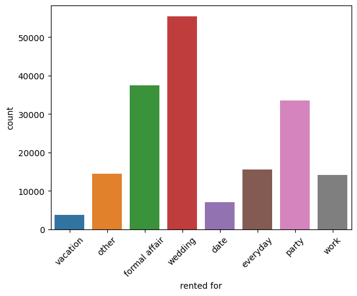

```python
sns.countplot(data=data, x='rented for')
plt.xticks(rotation=45)
plt.show()
```

### ● Data Preparation for model building:

### 12. Encode the categorical variables in the dataset.

```python
from sklearn.preprocessing import LabelEncoder

# Create a copy of the data
data_encoded = data.copy()

# Encode categorical variables using LabelEncoder
encoder = LabelEncoder()
categorical_cols = data.select_dtypes(include='object').columns

for col in categorical_cols:
    data_encoded[col] = encoder.fit_transform(data_encoded[col])

# Fill missing values with the mean
data_encoded.fillna(data_encoded.mean(), inplace=True)
```

### 13. Standardize the data, so that the values are within a particular range.

```python
scaled = StandardScaler().fit_transform(data_encoded.values)  # Standardize the data
data_scaled = pd.DataFrame(scaled, index=data_encoded.index, columns=data_encoded.columns)
```

```python
print(data_scaled[:3])
```

```
   Unnamed: 0       fit  bust size   item_id    weight    rating  rented for  \
0   -1.732384 -0.556702  -0.281908  1.512599 -0.012603  0.636280    0.504773
1   -1.732366 -0.556702  -0.372042 -1.106325 -0.262007  0.636280   -0.466270
3   -1.732330 -0.556702  -0.326975 -1.140059 -0.112364 -0.764607   -0.951792

   review_text  body type  review_summary  category    height      size  \
0    -1.648673  -0.141332        0.755894  1.577872  1.125538  0.232193
1    -0.624160   1.442545       -0.368636 -0.304775  0.454442 -0.006054
3    -0.571778   0.386627       -1.081298 -0.618549  0.118894 -0.482549

        age
0 -0.766386
1  0.548263
3  0.219601
```

### ● Principal Component Analysis and Clustering:

### 14. Apply PCA on the above dataset and determine the number of PCA components to be used so that 90-95% of the variance in data is explained by the same.

```python
pca = PCA(n_components=0.95)
pca_data = pca.fit_transform(data_scaled)
```

```python
cov_matrix = np.cov(data_scaled.T)
cov_matrix
```

[output not shown]

[output cut: 15 more lines]

[output not shown]

```python
eig_vals, eig_vectors = np.linalg.eig(cov_matrix)
print('eigin vals:','\n',eig_vals)
print('\n')
print('eigin vectors','\n',eig_vectors)
```

[output not shown]

[output cut: 8 more lines]

[output not shown]

```python
total = sum(eig_vals)
var_exp = [(i/total)*100 for i in sorted(eig_vals, reverse=True)]
cum_var_exp = np.cumsum(var_exp)
print('Explained Variance:', var_exp)
print('Cummulative Variance Explained:', cum_var_exp)
```

```
Explained Variance: [15.044705471819848, 9.588966511906477, 8.839071715092423, 7.7895119114481455, 7.661667412925587, 7.1949673398873, 7.142163940575724, 6.973477181073834, 6.586109234870601, 6.2709107748842445, 5.426860206142114, 4.90631498625513, 4.752949512567742, 1.8223238005508298]
Cummulative Variance Explained: [ 15.04470547  24.63367198  33.4727437   41.26225561  48.92392302
  56.11889036  63.2610543   70.23453148  76.82064072  83.09155149
  88.5184117   93.42472669  98.1776762  100.        ]
```

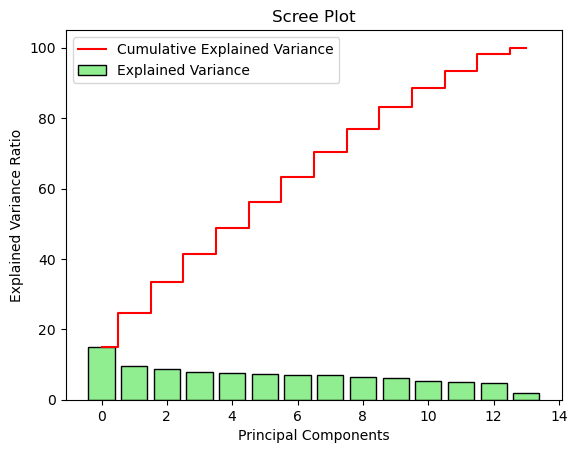

```python
plt.bar(range(len(var_exp)), var_exp, align='center', color='lightgreen', edgecolor='black', label='Explained Variance')
plt.step(range(len(var_exp)), cum_var_exp, where='mid', color='red', label='Cumulative Explained Variance')
plt.xlabel('Principal Components')
plt.ylabel('Explained Variance Ratio')
plt.title('Scree Plot')
plt.legend()
plt.show()
```

### 15. Apply K-means clustering and segment the data. (You may use original data or PCA transformed data)

### a. Find the optimal K Value using elbow plot for K Means clustering.

```python
inertia = []
```

```python
k_values = range(2, 11)
for k in k_values:
    # Create a K-means clustering model
    kmeans_model = KMeans(n_clusters=k, random_state=42)

    # Fit the model to the data
    kmeans_model.fit(data_scaled)  # Use the original scaled data or pca_data

    # Append the inertia value to the list
    inertia.append(kmeans_model.inertia_)
```

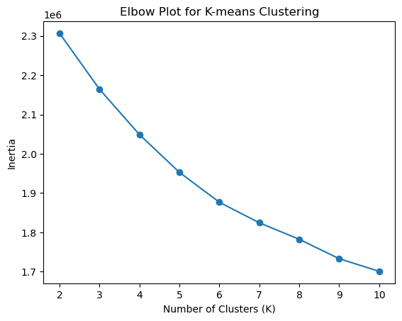

```python
plt.plot(k_values, inertia, marker='o')
plt.xlabel('Number of Clusters (K)')
plt.ylabel('Inertia')
plt.title('Elbow Plot for K-means Clustering')
plt.show()
```

### b. Build a Kmeans clustering model using the obtained optimal K value from the elbow plot.

```python
# Choose the optimal K value based on the elbow plot
optimal_k = 4
```

```python
# Create a K-means clustering model with the optimal K value
kmeans_model = KMeans(n_clusters=optimal_k, random_state=42)
```

```python
# Fit the model to the data
kmeans_model.fit(data_scaled)  # Use the original scaled data or pca_data
```

```
KMeans(n_clusters=4, random_state=42)
```

```python
# Get the cluster labels for the data
kmeans_labels = kmeans_model.labels_
```

### c. Compute silhouette score for evaluating the quality of the K Means clustering technique.

```python
from sklearn.metrics import silhouette_score
```

```python
silhouette_score = silhouette_score(data_scaled, kmeans_labels)  # Use the original scaled data or pca_data
```

```python
print("Silhouette Score for K-means Clustering:", silhouette_score)
```

```
Silhouette Score for K-means Clustering: 0.09366988808996263
```

### 16. Apply Agglomerative clustering and segment the data. (You may use original data or PCA transformed data)

### a. Find the optimal K Value using dendrogram for Agglomerative clustering.

```python
from scipy.cluster.hierarchy import dendrogram, linkage
import matplotlib.pyplot as plt
```

```python
sample_size = 1000
sample_data = data_encoded.sample(n=sample_size, random_state=42)
```

```python
linkage_matrix = linkage(sample_data, method='ward')
```

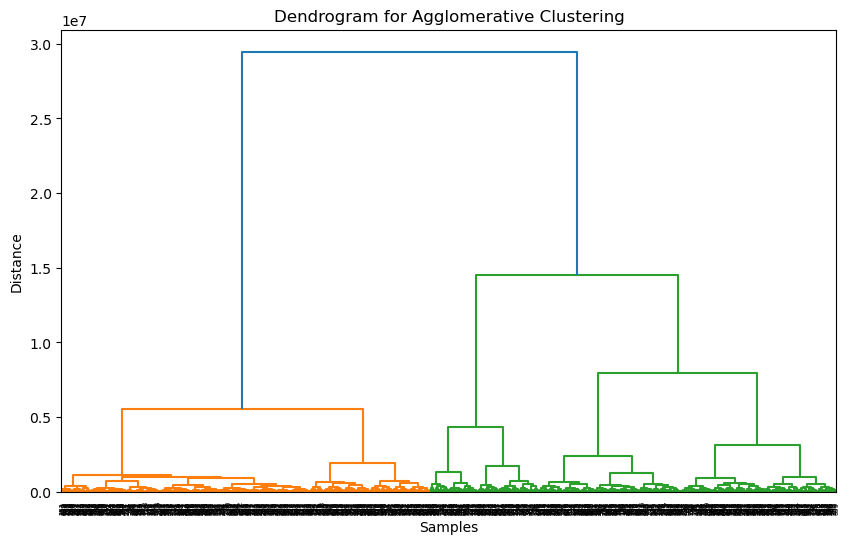

```python
plt.figure(figsize=(10, 6))
dendrogram(linkage_matrix)
plt.title('Dendrogram for Agglomerative Clustering')
plt.xlabel('Samples')
plt.ylabel('Distance')
plt.show()
```

### b. Build a Agglomerative clustering model using the obtained optimal K value observed from dendrogram.

```python
from sklearn.cluster import AgglomerativeClustering
```

```python
optimal_k = 4
```

```python
# Build the Agglomerative clustering model with the optimal K value
agglomerative_model = AgglomerativeClustering(n_clusters=optimal_k, affinity='euclidean', linkage='ward')
agglomerative_model.fit(sample_data)
```

```
AgglomerativeClustering(n_clusters=4)
```

```python
# Get the cluster labels for the sample data
agglomerative_labels = agglomerative_model.labels_
```

### c. Compute silhouette score for evaluating the quality of the Agglomerative clustering technique.

```python
from sklearn.metrics import silhouette_score
```

```python
agglomerative_silhouette_score = silhouette_score(sample_data, agglomerative_labels)
print("Silhouette Score for Agglomerative Clustering:", agglomerative_silhouette_score)
```

```
Silhouette Score for Agglomerative Clustering: 0.5391934494004634
```

```python
data['kmeans_Cluster'] = kmeans_labels
```

```python
agglomerative_labels_shortened = agglomerative_labels[:sample_data.shape[0]]
```

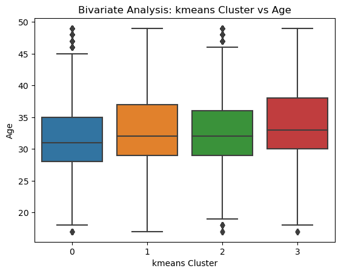

```python
sns.boxplot(x='kmeans_Cluster', y='age', data=data)
plt.xlabel('kmeans Cluster')
plt.ylabel('Age')
plt.title('Bivariate Analysis: kmeans Cluster vs Age')
plt.show()
```